# Lab 4 Team

Meredith Tucker, (mltucker2001) and Mike Zaino, (mzaino16)

3/11/2020

```r
defense <- read_excel('cyclonesFootball2019.xlsx', sheet='Defensive')
offense <- read_excel('cyclonesFootball2019.xlsx', sheet='Offensive')
biography <- read_excel('cyclonesFootball2019.xlsx', sheet='Biography')
```

# Part One

1.) The player names and opponent names are factors.

```r
defclean <- defense %>%
  mutate_at(c('Name', 'Opponent_Opponent'), factor)

offclean <- offense %>%
  mutate_at(c('Name', 'Opponent_Opponent'), factor)

bioclean <- biography %>%
  mutate_at(c('Name'), factor)
```

2.) All offensive and defensive statistics are numerical. The Weight column in biography is also numeric. (Hint: look at ?mutate_at if you want to save writing some code).

```r
defclean <- defclean %>%
  mutate_at(c(3,4,5,6,7,8,9,10,11), as.numeric)
offclean <- offclean %>%
  mutate_at(c(3,4,5,6,7,8,9,10,11, 12), as.numeric)
```

3.) Change the Height column in biogrpahy into numeric. (Hint: Use a unit that works well)

```r
bioclean <- bioclean %>%
  separate(Height, c('Feet', 'Inches'), sep='-', convert=TRUE) %>% mutate(cm = (12*Feet + Inches) *2.54)
```

```r
head(offclean)
```

```
## # A tibble: 6 x 12
##   Name  Opponent_Oppone… Rushing_ATT Rushing_YDS Rushing_TD Receiving_REC
##   <fct> <fct>                  <dbl>       <dbl>      <dbl>         <dbl>
## 1 Aker… UNI                        0           0          0             1
## 2 Aker… Iowa                       0           0          0             0
## 3 Aker… ULM                        1           8          0             0
## 4 Aker… Baylor                     0           0          0             0
## 5 Aker… TCU                        0           0          0             1
## 6 Aker… West Virginia              0           0          0             0
## # … with 6 more variables: Receiving_YDS <dbl>, Receiving_TD <dbl>,
## #   `Passing_CMP-ATT` <dbl>, Passing_YDS <dbl>, Passing_TD <dbl>,
## #   Passing_INT <dbl>
```

```r
head(defclean)
```

```
## # A tibble: 6 x 11
##   Name  Opponent_Oppone… Tackles_Solo Tackles_ASST Tackles_TFL Tackles_Sack
##   <fct> <fct>                   <dbl>        <dbl>       <dbl>        <dbl>
## 1 Whit… UNI                         4            4           0            0
## 2 Whit… Iowa                        4            7           0            0
## 3 Whit… ULM                         3            5           0            0
## 4 Whit… Baylor                      4            2           0            0
## 5 Whit… TCU                         3            2           1            0
## 6 Whit… West Virginia               1            1           0            0
## # … with 5 more variables: Turnover_FF <dbl>, Turnover_FR <dbl>,
## #   Turnover_INT <dbl>, Pass_QBH <dbl>, Pass_PB <dbl>
```

```r
head(bioclean)
```

```
## # A tibble: 6 x 9
##   Name     Position   Feet Inches Weight Class   Hometown  Highschool    cm
##   <fct>    <chr>     <int>  <int> <chr>  <chr>   <chr>     <chr>      <dbl>
## 1 Akers, … Wide Rec…     6      0 188    Redshi… Cedar Ra… Washington  183.
## 2 Allen, … Tight End     6      7 245    Redshi… Nixa, Mo. Nixa        201.
## 3 Anderso… Wide Rec…     6      5 204    Redshi… Seffner,… Armwood     196.
## 4 Assalle… Placekic…     6      0 195    Redshi… Napervil… Central     183.
## 5 Azunna,… Defensiv…     6      0 190    Redshi… Grand Pr… Lake Ridge  183.
## 6 Bailey,… Defensiv…     6      3 235    Redshi… Clarksda… Clarksdale  190.
```

# Part 2

For the following questions, work on the cleaned data frames defClean, offClean, and bioClean.

1.) Reformat the defClean data frame into a tidy format using pivot_longer. The type of statistic (Tackles_Solo, Tackles_ASST, etc) is added as a new key column named Statistic.

```r
longdefclean <- defclean %>%
  pivot_longer(c(3:11), names_to='Statistic', values_to='Score')
```

2.) Create a histogram for each defensive statistic. Use facet_wrap to draw all histograms in a single plot. What defensive skills are rare?

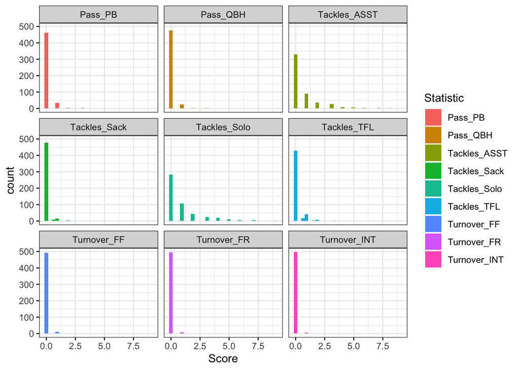

```r
longdefclean %>%
  ggplot(aes(x=Score, fill=Statistic))+geom_histogram()+theme_bw()+facet_wrap(~Statistic)
```

Looking at the histograms, we can see that all turnovers are rare. These are forced fumbles, fumble recoveries, and interceptions.

3.) Did ISU have better defense against West Virginia or Kansas State? Answer this question by creating a scatterplot with x-axis being the number of solo tackles (by each player) against West Virginia, and y-axis being that against Kansas State. A large number of solo tackles indicates good defense.

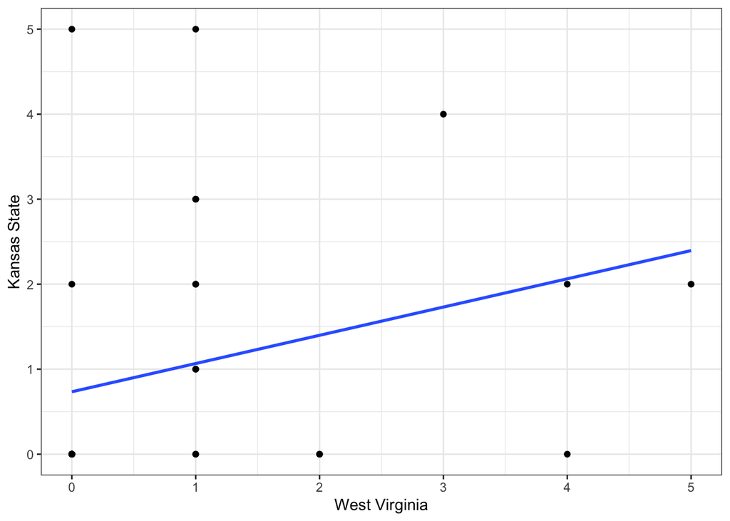

```r
longdefclean %>%
  filter(Opponent_Opponent == 'West Virginia' | Opponent_Opponent =='Kansas State') %>%
  filter(Statistic == 'Tackles_Solo') %>%
  group_by(Name) %>%
  mutate(Count = n()) %>%
  filter(Count== 2) %>%
  ungroup() %>%
  pivot_wider(names_from = Opponent_Opponent, values_from = Score) %>%
  ggplot(aes(x=`West Virginia`, y=`Kansas State`)) + geom_point() + stat_smooth(method='lm', se=FALSE)+theme_bw()
```

1.) Separate the Hometown column into two columns, namely the city and the state. Print the first few rows of these two columns. (Hint: look at the sep= argument of separate)

```r
bioclean <- bioclean %>%
  separate(Hometown, c('City', 'State'), sep=',', convert=TRUE)
head(bioclean)
```

```
## # A tibble: 6 x 10
##   Name    Position   Feet Inches Weight Class  City  State Highschool    cm
##   <fct>   <chr>     <int>  <int> <chr>  <chr>  <chr> <chr> <chr>      <dbl>
## 1 Akers,… Wide Rec…     6      0 188    Redsh… Ceda… " Io… Washington  183.
## 2 Allen,… Tight End     6      7 245    Redsh… Nixa  " Mo… Nixa        201.
## 3 Anders… Wide Rec…     6      5 204    Redsh… Seff… " Fl… Armwood     196.
## 4 Assall… Placekic…     6      0 195    Redsh… Nape… " Il… Central     183.
## 5 Azunna… Defensiv…     6      0 190    Redsh… Gran… " Te… Lake Ridge  183.
## 6 Bailey… Defensiv…     6      3 235    Redsh… Clar… " Mi… Clarksdale  190.
```

2.) How many players are there from each state?

```r
bioclean %>%
  group_by(State) %>%
  summarize(n=n())
```

```
## # A tibble: 19 x 2
##    State            n
##    <chr>        <int>
##  1 " Ariz."         4
##  2 " Ark."          1
##  3 " Australia"     1
##  4 " Calif."        3
##  5 " Fla."         10
##  6 " Ga."           4
##  7 " Ill."          5
##  8 " Iowa"         35
##  9 " Kan."          3
## 10 " Mich."         4
## 11 " Minn."         4
## 12 " Miss."         1
## 13 " Mo."           6
## 14 " Ohio"          7
## 15 " Okla."         2
## 16 " Pa."           1
## 17 " S.D."          2
## 18 " Texas"         6
## 19 " Wis."          6
```

# Part 3

1.Find where do the offensive players come from by joining the offensive data and player biography data appropriately.

```r
offbioclean <- offclean %>%
  inner_join(bioclean)
```

2.Is there a relationship between the weight of a player and the receiving yards (Receiving_YDS)?

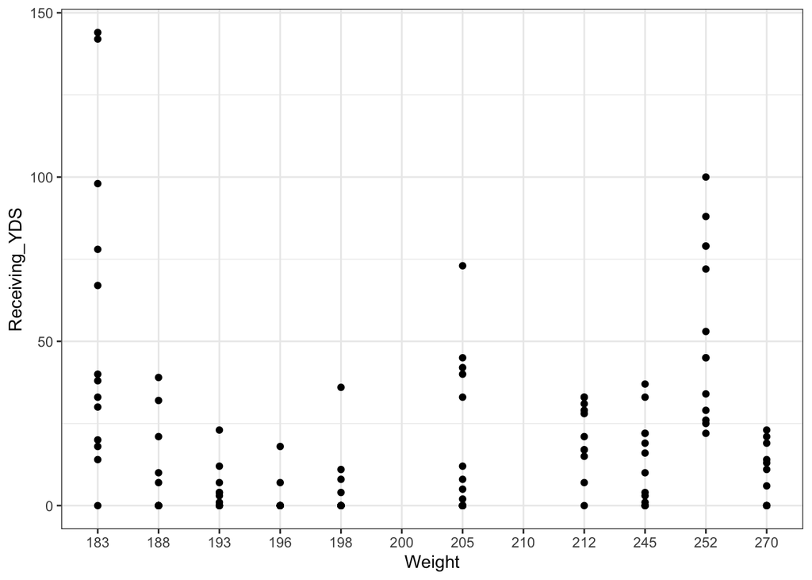

```r
offbioclean %>%
  ggplot(aes(x=Weight, y=Receiving_YDS))+geom_point()+theme_bw()+stat_smooth(method="lm", se=FALSE)
```

There is no relationship between weight and receiving yards.

3.How do the performance of quarterback Brock Purdy relate to the performance of the ISU team?

```r
offbioclean
```

```
## # A tibble: 152 x 21
##    Name  Opponent_Oppone… Rushing_ATT Rushing_YDS Rushing_TD Receiving_REC
##    <chr> <fct>                  <dbl>       <dbl>      <dbl>         <dbl>
##  1 Aker… UNI                        0           0          0             1
##  2 Aker… Iowa                       0           0          0             0
##  3 Aker… ULM                        1           8          0             0
##  4 Aker… Baylor                     0           0          0             0
##  5 Aker… TCU                        0           0          0             1
##  6 Aker… West Virginia              0           0          0             0
##  7 Aker… Texas Tech                 0           0          0             0
##  8 Aker… Oklahoma State             0           0          0             4
##  9 Aker… Oklahoma                   0           0          0             0
## 10 Aker… Texas                      0           0          0             1
## # … with 142 more rows, and 15 more variables: Receiving_YDS <dbl>,
## #   Receiving_TD <dbl>, `Passing_CMP-ATT` <dbl>, Passing_YDS <dbl>,
## #   Passing_TD <dbl>, Passing_INT <dbl>, Position <chr>, Feet <int>,
## #   Inches <int>, Weight <chr>, Class <chr>, City <chr>, State <chr>,
## #   Highschool <chr>, cm <dbl>
```

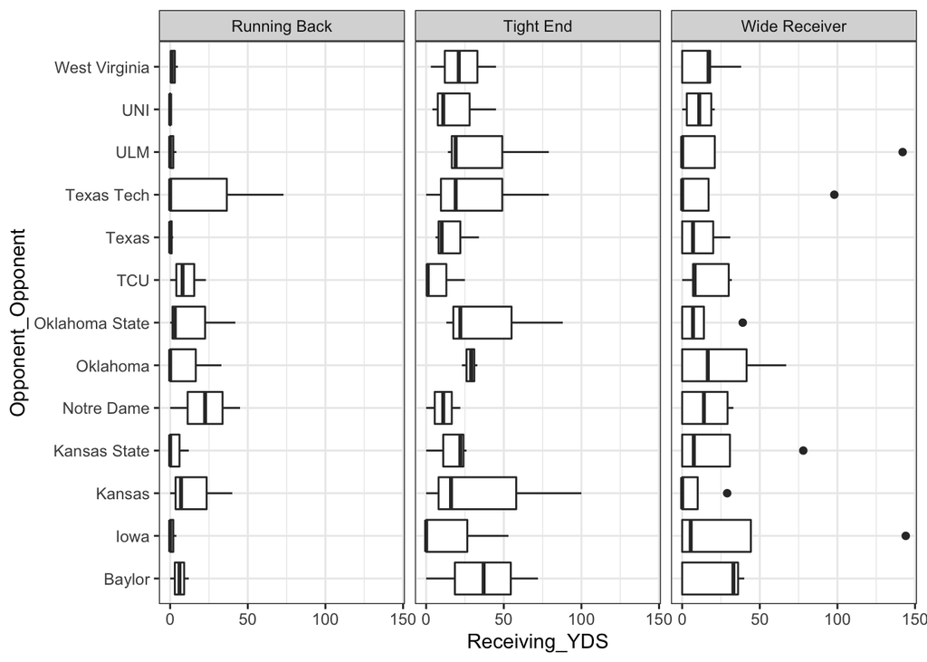

```r
offbioclean %>%
  filter(Position %in% c('Wide Receiver', "Running Back", "Tight End")) %>%
  ggplot(aes(x=Opponent_Opponent, y=Receiving_YDS))+geom_boxplot()+theme_bw()+coord_flip()+facet_wrap(~Position)
```

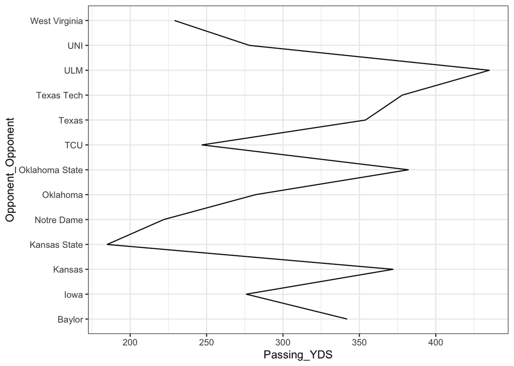

```r
offbioclean %>%
  filter(Position == 'Quarterback') %>%
  ggplot(aes(x=Opponent_Opponent, y=Passing_YDS, group=1))+geom_line()+theme_bw()+coord_flip()
```

4.Explore more. You may in addition explore the 2018 data here. Raise a question that can be answered only by looking at two or more data frames. Then answer that question.

Does your class determine the amount of receiving yards you are going to have?

```r
table(offbioclean$Class)
```

```
##
##             Junior  Redshirt Freshman    Redshirt Junior
##                 26                  4                 38
##    Redshirt Senior Redshirt Sophomore          Sophomore
##                 51                 21                 12
```

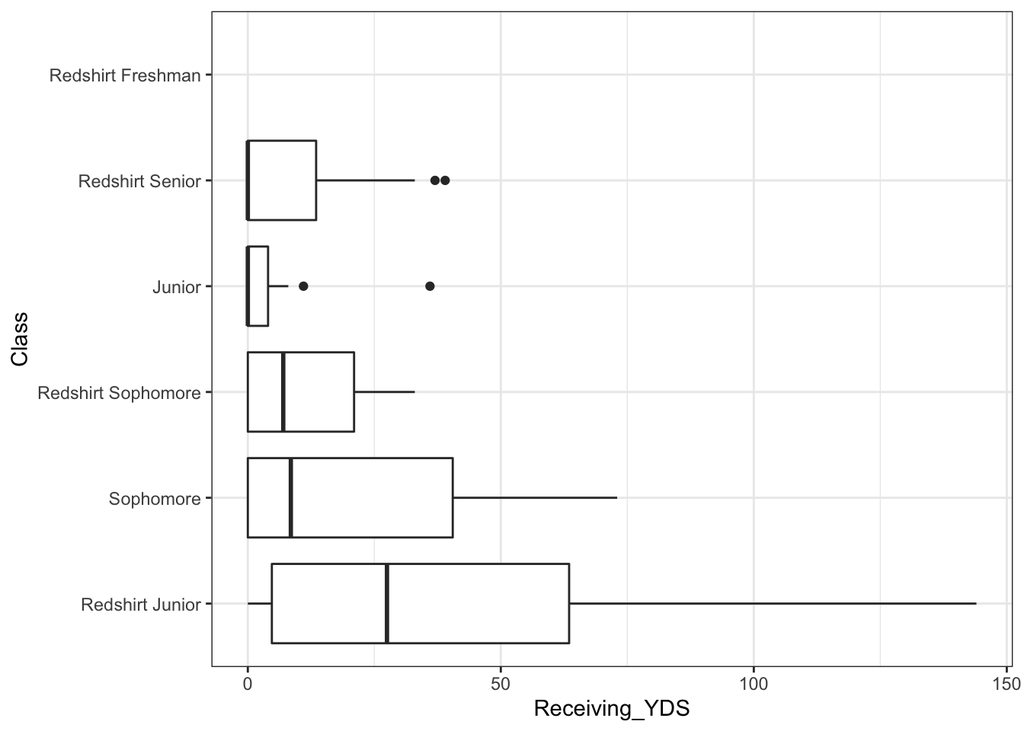

```r
offbioclean %>%
  filter(Position %in% c("Wide Receiver", "Tight End", "Running Back")) %>%
  mutate(Class = fct_reorder(Class, desc(Receiving_YDS))) %>%
  group_by(Class) %>%
  ggplot(aes(x=Class, y= Receiving_YDS))+geom_boxplot()+theme_bw()+coord_flip()
```